# Aides Drug

Ashley Word Ycaza

May 31

# 1 Introduction

A new preventative aides (abacavirinol) is under test in clinical trials. Analyze the effectiveness of this drug across the board. Consider population subgroups by gender, drug use, and sexual orientation.

the first question is this: does abacavirinol have any effect on whether one contracts aids or not?

$H_0:$ abacavirinol has no effect on whether one contracts aids or not  
$H_1:$ abacavirinol has an effect on whether one contracts aids or not

the remaining questions are: does abacavirinol have a different effect based on gender?

$H_0:$ gender has no effect on whether abacavirinol effectd against contracting aids  
$H_1:$ gender does effect whether abacavirinol has an effect on contracting aids

does abacavirinol have a different effect based on drug use?

$H_0:$ drug use has no effect on whether abacavirinol has an effect on contracting aids  
$H_1:$ drug use does have an effect on whether abacavirinol has an effect on contracting aids

does abacavirinol have a different effect based on sexual orientation?

$H_0:$ sexual orientaion has no effect on whether abacavirinol has an effect on contracting aids  
$H_1:$ sexual orientation does have an effect on whether abacavirinol has an effect on contracting aids

# 2 Methods

for each hypothesis test, the graphical summary will be a bar chart, the numerical summary will be a cross tabulation, and a chi-squared test will be used for the inferential results

# 3 Results General Effectiveness

Is the vaccine effective on the general population

## 3.1 Descriptive Results

### 3.1.1 Graphical Descriptive Results

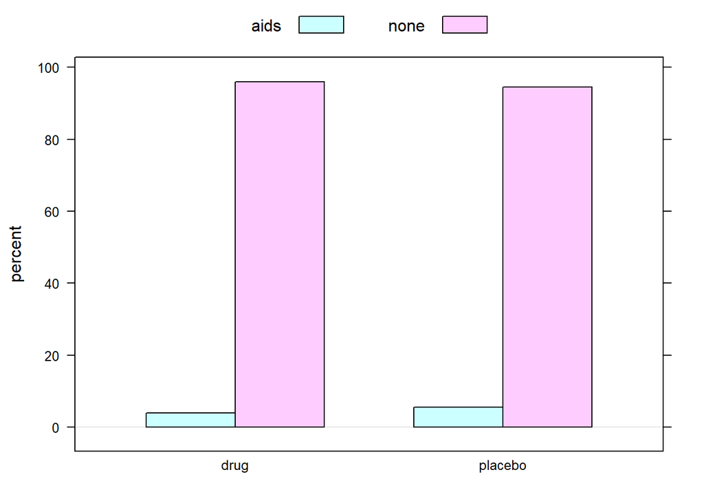

```r
barchartGC(~treatment+infected, data=avast, type= "percent")
```

### 3.1.2 Numerical Descriptive Results

```r
genTable = xtabs(~treatment+infected, data=avast)
print(genTable)
```

```
##          infected
## treatment  aids  none
##   drug      423 10168
##   placebo   612 10540
```

## 3.2 Inferential Results

```r
chisq.test(genTable)
```

```
##
##  Pearson's Chi-squared test with Yates' continuity correction
##
## data:  genTable
## X-squared = 26.41, df = 1, p-value = 2.761e-07
```

# 4 Results Gender effects

does gender have an effect on abacavirinol effectiveness

## 4.1 Descriptive Results

### 4.1.1 Graphical Descriptive Results

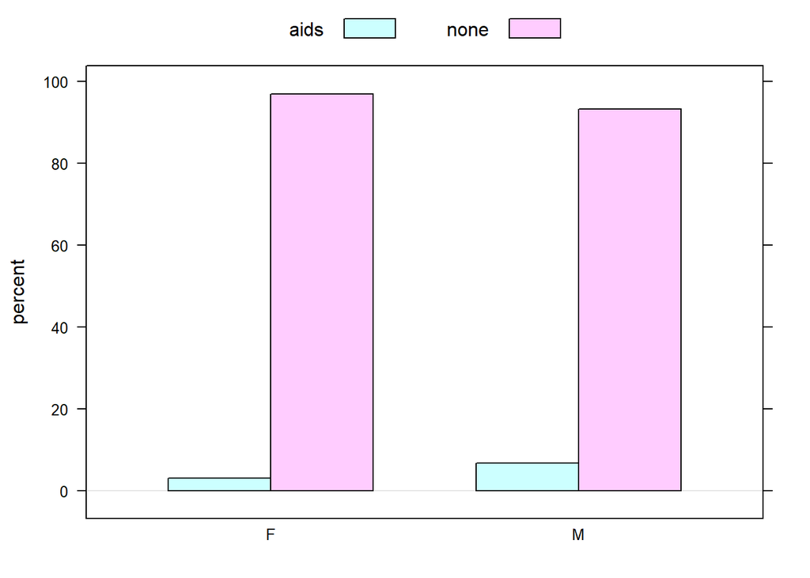

```r
barchartGC(~sex+infected, data=avast, type= "percent")
```

### 4.1.2 Numerical Descriptive Results

```r
genTable = xtabs(~sex+infected, data=avast)
print(genTable)
```

```
##    infected
## sex  aids  none
##   F   357 11411
##   M   678  9297
```

## 4.2 Inferential Results

```r
chisq.test(genTable)
```

```
##
##  Pearson's Chi-squared test with Yates' continuity correction
##
## data:  genTable
## X-squared = 167.83, df = 1, p-value < 2.2e-16
```

# 5 Results Drug Effects

does drug use have an effect on abacavirinol effectiveness

## 5.1 Descriptive Results

### 5.1.1 Graphical Descriptive Results

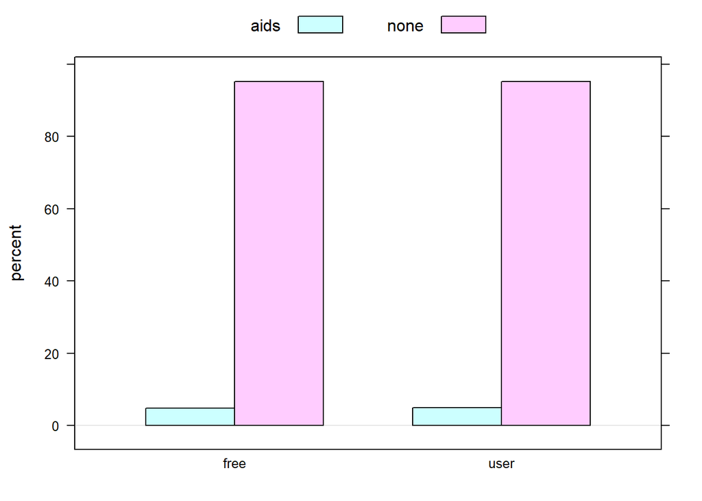

```r
barchartGC(~Ivdrug+infected, data=avast, type= "percent")
```

### 5.1.2 Numerical Descriptive Results

```r
genTable = xtabs(~Ivdrug+infected, data=avast)
print(genTable)
```

```
##       infected
## Ivdrug  aids  none
##   free   930 18655
##   user   105  2053
```

## 5.2 Inferential Results

```r
chisq.test(genTable)
```

```
##
##  Pearson's Chi-squared test with Yates' continuity correction
##
## data:  genTable
## X-squared = 0.035789, df = 1, p-value = 0.85
```

# 6 Results Sexual Orientation Effects

does sexual orientation have an effect on abacavirinol effectiveness

## 6.1 Descriptive Results

### 6.1.1 Graphical Descriptive Results

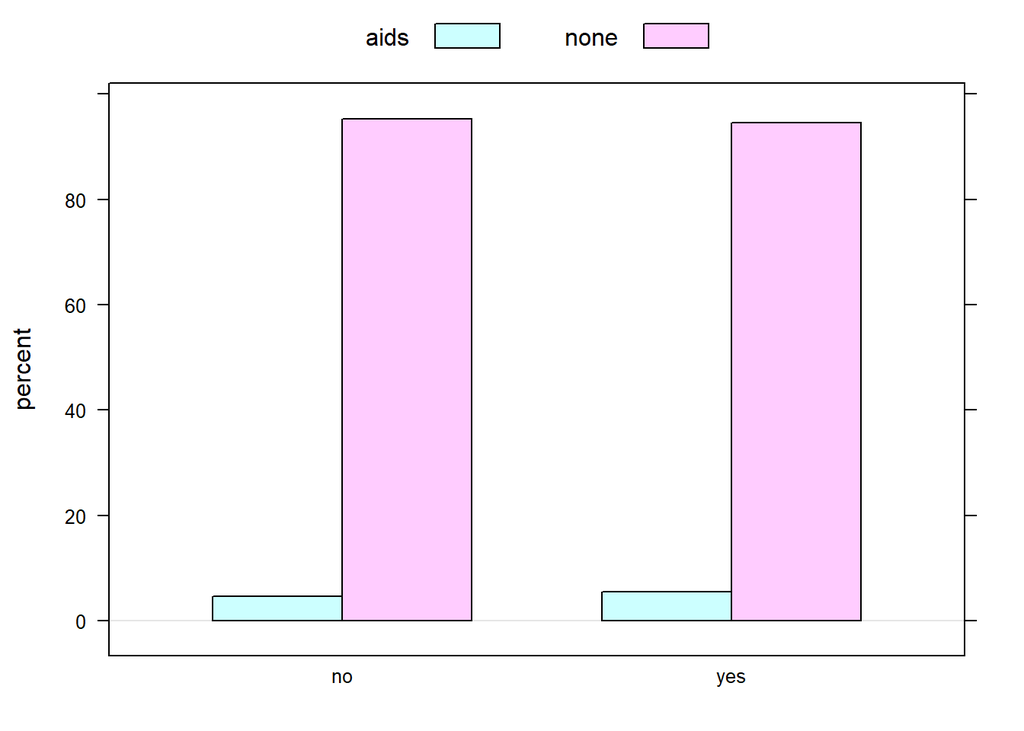

```r
barchartGC(~LBGT+infected, data=avast, type= "percent")
```

### 6.1.2 Numerical Descriptive Results

```r
genTable = xtabs(~LBGT+infected, data=avast)
print(genTable)
```

```
##      infected
## LBGT   aids  none
##   no    895 18306
##   yes   140  2402
```

## 6.2 Inferential Results

```r
chisq.test(genTable)
```

```
##
##  Pearson's Chi-squared test with Yates' continuity correction
##
## data:  genTable
## X-squared = 3.3619, df = 1, p-value = 0.06672
```

# 7 Discussion and Conclusion

gender does effect whether abacavirinol has an effect on contracting aids

drug use has no effect on whether abacavirinol has an effect on contracting aids

sexual orientaion has no effect on whether abacavirinol has an effect on contracting aids